# Amu Notes

- Hybrid Rules & Data approach required

# Echo Bot

```python
print('Hello, nice to meet you ')
print('I am a chatbot that will echo what you say.')

stuff_to_echo = input('What do you have to say? \n')

print("You said: "  + str(stuff_to_echo))
```

```
Hello, nice to meet you
I am a chatbot that will echo what you say.
What do you have to say?
banana
You said: banana
```

# Types of Chatbots

### Classify based upon 3 domains

- Response domains
- Conversation domain (open/closed)
- Initiative Domain (who starts the convo)

## Response types

chatbots can be categorized according to how they generate the response that gets returned to the user.

- `rule-based model` (including decision trees)
- `retrieval-based model` pulls from db
- `ML optimised retrieval-based model`, these can self learn, although the responses are still static, the selection of responses are intelligent
- `generative chatbot` are capable of formulating their own original responses based on user input, rather than relying on existing text. This involves the use of deep learning, such as `LSTM-based` `seq2seq models`, to train the chatbots to be able to make decisions about what is an appropriate response to return.

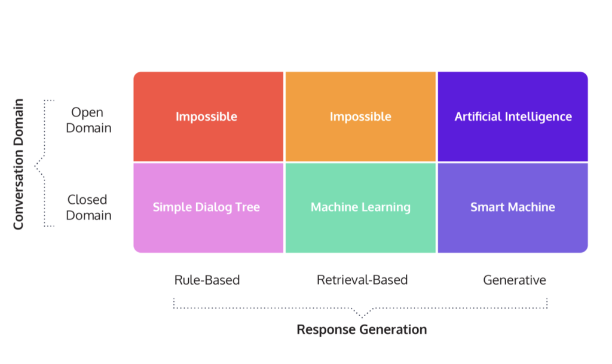

## Closed domain chatbots

Good for booking a room, getting specific results

## PARRY

Kenneth Colby developed PARRY while at Stanford University in 1968. Colby built PARRY with a similar rule-based method to ELIZA. However, it was designed to model the behavior of a person with diagnosable paranoia. PARRY also had a richer response library and was able to simulate the mood of a person by shifting weights of mood parameters. PARRY would respond differently based on the distribution between mood parameters for anger, fear, or mistrust. PARRY passed a modified Turing Test by fooling people who tried to distinguish the difference between it and a person with paranoia.

## A.L.I.C.E.(Artificial Linguistic Internet Computer Entity)

Richard Wallace started developing A.L.I.C.E. in 1995, shortly before leaving his computer vision teaching job. Wallace improved upon ELIZA’s implementation by continuing to watch the model while it had conversations with people. If a person asked an A.L.I.C.E. bot something it did not recognize, Wallace would add a response for it. In this way, the person who designs an A.L.I.C.E.-powered device could continuously modify it by adding responses to unrecognized phrases. This means that well-developed A.L.I.C.E. bots can respond to a variety of questions and statements based on the developer’s needs. In a chapter from the 2009 book, Parsing the Turing Test, Richard Wallace described this process as supervised learning, because the developer – who he calls the botmaster – can supervise the learning of the model. \

In 2000, 2001, and 2004, A.L.I.C.E., won the Loebner prize, which is a contest that was started in 1980 to award computer programs that are the most human-like. The Loebner prize is awarded to the bot that performs the best on the Turing Test. The judges of the Loebner competition have two conversations simultaneously. One with a real person and the other with a bot. The winner of the competition is the one that tricks a judge the highest percentage of the time.

## Jabberwacky

Jabberwacky was developed by Rollo Carpenter in the 1980s and was launched on the web in 1997. It was the first chatbot that tried to incorporate voice interaction. Two versions of Jabberwacky won the Loebner prize in 2005 and 2006. Jabberwacky has undergone continuous development since it debuted on the web. When it launched, it used a similar rule-based approach to previous models, like ELIZA and PARRY. However, in 2008, the model was renamed Cleverbot and updated to include a method for learning without the supervision of a botmaster. Cleverbot can parse and save human responses to questions, and respond similarly if a human asked it the same question.

## Mitsuku

Mitsuku was developed by Steve Worswick during the early 2000s and first won the Loebner prize in 2013. The model is still actively developed and has won the Loebner Prize in 2016, 2017, 2018, and 2019, making it the most human-like chatbot available. Mitsuku works more like the A.L.I.C.E. It is a supervised learning model, where developers actively tweak the rules to make interactions with Mitsuku more human-like.

Over 60 years ago, Alan Turing predicted we wouldn’t be able to distinguish humans from robots by now. If Turing saw the progress we’ve made, would he be impressed? It’s impossible to know. However, it’s unlikely he would have predicted the market potential of chatbot technology – some expect Alexa sales will be $19 billion by 2021. Products like Alexa, however, are highly integrated, drawing on many other technologies and systems in addition to chatbot software. Alexa falls well short of competing with Mitsuku in carrying out a conversation.

With the growing market for chatbot-driven technologies, there is far more money and interest in chatbot development than just a few years ago. In 2017, Amazon started the Alexa challenge, where teams compete to develop a chatbot that has the best conversation with users. The winners of this challenge receive $500,000, and Amazon tests each model’s ability to converse on Alexa devices.

We’ve made a lot of progress developing bots to beat the Imitation Game, but there is still progress to be made. Based on the growing interest in the field, it’s safe to expect significant progress in the coming years.

# Simple coffee bot

```python
# Define your functions

def coffee_bot():
  # ----- Greeting
  print('Welcome to the cafe!')
  # ----- Get core inputs
  size       = get_size()
  drink_type = get_drink_type()
  print("Alright, that's a {} {}!".format(size,drink_type))

  name = input("Can I get your name please? \n")
  print("Thanks, {}! your drink will be ready shortly.".format(name))

def get_size():
  res = input('What size drink can I get for you? \n[a] Small \n[b] Medium \n[c] Large \n> ')
  if(res=='a'):
    return('small')
  elif(res=='b'):
    return('medium')
  elif(res=='c'):
    return('large')
  else:
    print_message()
    res = get_size()
    return(res)

def get_drink_type():
  res = input("What type of drink would you like? \n [a] Brewed Coffee \n [b] Mocha \n [c] Latte \n")
  if(res=='a'):
    return('brewed coffee')
  elif(res=='b'):
    return('mocha')
  elif(res=='c'):
    res = order_latte()
    return(res)
  else:
    print_message()
    res = get_drink_type()
    return(res)

def order_latte():
  res = input("And what kind of milk for your latte? \n [a] 2% milk \n [b] Non-fat milk \n [c] Soy milk \n")
  if(res=='a'):
    return('latte')
  elif(res=='b'):
    return('Non-fat latte')
  elif(res=='c'):
    return('Soy latte')
  else:
    print_message()
    res = order_latte()
    return(res)

def print_message():
  print("I'm sorry, I did not understand your selection. Please enter the corresponding letter for your response.")

# Call coffee_bot()!

coffee_bot()
```

```
Welcome to the cafe!
What size drink can I get for you?
[a] Small
[b] Medium
[c] Large
> a
What type of drink would you like?
 [a] Brewed Coffee
 [b] Mocha
 [c] Latte
b
Alright, that's a small mocha!
Can I get your name please?
Adam
Thanks, Adam! your drink will be ready shortly.
```